# Data Science Capstone - Milestone Report

Vasudevan Durairaj

August 3, 2018

## Text mining and N-grams

### Background

This report was designed as part of Data Science Capstone project in the field of Natural Language Processing. It would demonstrate the data scientist’s ability to process and analyze large volumes of unstructured text.

The Projects’s final deliverable would be an algorithm that predicts the next word in a provided text with inputs from the test data set, similar to the predictive text functions found on today’s modern smart phones.

### About Dataset

The Swiftkey dataset part of HC Corpora is comprised of the output of lots of news sites, blogs and twitter. The dataset contains 3 files across four languages (Russian, Finnish, German and English). This project will focus on the English language datasets. The names of the data files are as follows:

1. en_US.blogs.txt
2. en_US.twitter.txt
3. en_US.news.txt

and these will be referred to as “Blogs”, “Twitter” and “News” for the remainder of this report

### Tasks Performed on the data

1. Explore the training Data Set
2. Profanity Filtering - removing profanity and other words that don’t want be included in the prediction model
3. Tokenization - identifying appropriate tokens such as words, punctuation and numbers

### Getting and Cleaning Data

The Captstone training datasets for this project were downloaded from the below link

https://d396qusza40orc.cloudfront.net/dsscapstone/dataset/Coursera-SwiftKey.zip

```r
## Code to download the file and unzip is hidden and its with the assumption that files are available in the current working directory
## Open the file connection
blogsC <- file("./final/en_US/en_US.blogs.txt", "r")
newsC  <- file("./final/en_US/en_US.news.txt", "r")
twitterC <- file("./final/en_US/en_US.twitter.txt", "r")

blogs <- readLines(blogsC, n=-1, encoding = "UTF-8")
news  <- readLines(newsC, n= -1, encoding = "UTF-8")
twitter <- readLines(twitterC, n=-1, encoding = "UTF-8")

## Close the file connection
close(blogsC)
close(newsC)
close(twitterC)

## compute no. of characters
nCharBlogs <- sum(nchar(blogs))
nCharNews <- sum(nchar(news))
nCharTwitter <- sum(nchar(twitter))

## compute no. of lines
lenBlogs <- length(blogs)
lenNews <- length(news)
lentwitter <- length(twitter)

## compute no. of words
nWordsBlogs <- sum(sapply(strsplit(blogs, " "), length))
nWordsNews  <- sum(sapply(strsplit(news," "), length))
nWordsTwitter <- sum(sapply(strsplit(twitter," "), length))

## Build a Dataset Summary output Table
outputTable <- data.frame(c("blogs", "news", "twitter"),c(nCharBlogs,nCharNews, nCharTwitter), c(lenBlogs, lenNews, lentwitter), c(nWordsBlogs, nWordsNews, nWordsTwitter))
colnames(outputTable) <- c("FileType", "Characters", "Lines", "Words")

## Release object memory
rm(blogs, news, twitter)

## Summary of Data Analysis
outputTable
```

```
##   FileType Characters   Lines    Words
## 1    blogs  206824505  899288 37334131
## 2     news   15639408   77259  2643969
## 3  twitter  162096031 2360148 30373543
```

### Exploratory Analysis of Data

Since the training data set size is huge, a sample of each file is extracted and explored for further study

```r
## Set the line count information for extraction
linesToExtract <- 10000

## Open the file connection
blogsC <- file("./final/en_US/en_US.blogs.txt", "r")
newsC  <- file("./final/en_US/en_US.news.txt", "r")
twitterC <- file("./final/en_US/en_US.twitter.txt", "r")

blogsS <- readLines(blogsC, n=linesToExtract, encoding = "UTF-8")
newsS  <- readLines(newsC, n= linesToExtract, encoding = "UTF-8")
twitterS <- readLines(twitterC, n=linesToExtract, encoding = "UTF-8")

## Close the file connection
close(blogsC)
close(newsC)
close(twitterC)

## compute no. of characters
nCharBlogs <- sum(nchar(blogsS))
nCharNews <- sum(nchar(newsS))
nCharTwitter <- sum(nchar(twitterS))

## compute no. of lines
lenBlogs <- length(blogsS)
lenNews <- length(newsS)
lentwitter <- length(twitterS)

## compute no. of words
nWordsBlogs <- sum(sapply(strsplit(blogsS, " "), length))
nWordsNews  <- sum(sapply(strsplit(newsS," "), length))
nWordsTwitter <- sum(sapply(strsplit(twitterS," "), length))

## Build a Dataset Summary output Table
sampleOutputTable <- data.frame(c("blogsSample", "newsSample", "twitterSample"),c(nCharBlogs,nCharNews, nCharTwitter), c(lenBlogs, lenNews, lentwitter), c(nWordsBlogs, nWordsNews, nWordsTwitter))
colnames(sampleOutputTable) <- c("FileType", "Characters", "Lines", "Words")

## Sample output summary table
sampleOutputTable
```

```
##        FileType Characters Lines  Words
## 1   blogsSample    2277384 10000 410620
## 2    newsSample    2035687 10000 343929
## 3 twitterSample     681544 10000 127674
```

#### Data Cleansing & Corpora building

The text sample extracted from each of the files is transformed step-by-step for Predictive Model bulding

```r
## Libraries to be loaded for Data Analysis
suppressMessages(library(NLP))
suppressMessages(library(openNLP))
suppressMessages(library(qdapDictionaries))
suppressMessages(library(qdap))
suppressMessages(library(qdapRegex))
suppressMessages(library(qdapTools))
suppressMessages(library(slam))
suppressMessages(library(tm))
suppressMessages(library(RWeka))
suppressMessages(library(ngram))
suppressMessages(library(stringr))
suppressMessages(library(RColorBrewer))
suppressMessages(library(SnowballC))
suppressMessages(library(wordcloud))
suppressMessages(library(ggplot2))
suppressMessages(library(dplyr))

## Collate Sample Text Data and create a reduced raw data file before processing
##beforeData <- c(blogsS, newsS, twitterS)
beforeDF <- data.frame(text=c(blogsS, newsS, twitterS))
beforeCorpora <- VCorpus(VectorSource(beforeDF))
sampleTxtBP <- strwrap(head(beforeCorpora[[1]]$content,5))

## Remove retweets from Twitter Data Sample
twitterS <- gsub ("(RT|via)((?:\\b\\W*@\\w+)+)", "", twitterS)

## Remove @people names from Twitter
twitterS <- gsub("@\\w+", "",twitterS)

## Collate text data from different file samples
sampleData <- c(blogsS, newsS, twitterS)

## Replace abbreviation so that the sentences are not split at incorrect places
sampleData <- replace_abbreviation(sampleData)

## convert paragraphs to sentences
##endNotations <- c("?", ".", ",","!", "|", ":", "\n", "\r\n")
##sampleData <- sent_detect (sampleData, endmarks = endNotations, rm.bracket = FALSE)

## Collate Sample Text Data and create a reduced raw data file
sampleDF<- data.frame(text = sampleData)

## Create Text Corpus for processing
sampleCorpora <- VCorpus(VectorSource(sampleDF))

## Release object memory
rm(blogsS, newsS, twitterS)
rm(beforeDF, beforeCorpora,sampleDF,sampleData)

## convert the text to lower case
sampleCorpora <- tm_map(sampleCorpora,content_transformer(tolower))

## Remove URL from Corpora
removeOnlineJunk <- function(x) {
    # replace emails and such but space
    x <- gsub("[^ ]{1,}@[^ ]{1,}"," ",x)
    x <- gsub(" @[^ ]{1,}"," ",x)
    # hashtags
    x <- gsub("#[^ ]{1,}"," ",x)
    # websites and file systems
    x <- gsub("[^ ]{1,}://[^ ]{1,}"," ",x)
}
sampleCorpora <- tm_map(sampleCorpora,content_transformer(removeOnlineJunk))

## Remove symbols
removeSymbols <- function(x){
    # Edit out most non-alphabetical character
    # text must be lower case first
    x <- gsub("[`'']","'",x)
    x <- gsub("[^a-z']"," ",x)
    x <- gsub("'{2,}"," '",x)
    x <- gsub("' "," ",x)
    x <- gsub(" '"," ",x)
    x <- gsub(","," ",x)
    x <- gsub("^'","",x)
    x <- gsub("'$","",x)
    x
}
sampleCorpora <- tm_map(sampleCorpora,content_transformer(removeSymbols))

#remove the punctuations after trimming leading & trailing white spaces
sampleCorpora <- tm_map(sampleCorpora, content_transformer(removePunctuation))

## remove numbers from the text
sampleCorpora <- tm_map(sampleCorpora, content_transformer(removeNumbers))

## Build profane word list
profanityFileName = "profanity.txt"
if (!file.exists(profanityFileName))
download.file(url =  "http://www.cs.cmu.edu/~biglou/resources/bad-words.txt",destfile = profanityFileName)
profC <- file("./profanity.txt", "r")
profanityL<- readLines(profC, n=-1,encoding = "UTF-8")
close(profC)

## Remove profane words from the corpora
sampleCorpora <- tm_map(sampleCorpora, removeWords, profanityL)

## Finally remove all the white space that was created by the removals
sampleCorpora <- tm_map(sampleCorpora,content_transformer(stripWhitespace))

## Sample Text Data after processing
sampleTxtAP <- strwrap(head(sampleCorpora[[1]]$content,5))
```

Please find below the first few lines of text data before and after processing in the Corpora

```r
## Before Text processing
sampleTxtBP
```

```
##  [1] "In the years thereafter, most of the Oil fields and platforms were"
##  [2] "named after pagan gods."
##  [3] "We love you Mr. Brown."
##  [4] "Chad has been awesome with the kids and holding down the fort"
##  [5] "while I work later than usual! The kids have been busy together"
##  [6] "playing Skylander on the XBox together, after Kyan cashed in his"
##  [7] "$$$ from his piggy bank. He wanted that game so bad and used his"
##  [8] "gift card from his birthday he has been saving and the money to"
##  [9] "get it (he never taps into that thing either, that is how we know"
## [10] "he wanted it so bad). We made him count all of his money to make"
## [11] "sure that he had enough! It was very cute to watch his reaction"
## [12] "when he realized he did! He also does a very good job of letting"
## [13] "Lola feel like she is playing too, by letting her switch out the"
## [14] "characters! She loves it almost as much as him."
## [15] "so anyways, i am going to share some home decor inspiration that i"
## [16] "have been storing in my folder on the puter. i have all these"
## [17] "amazing images stored away ready to come to life when we get our"
## [18] "home."
## [19] "With graduation season right around the corner, Nancy has whipped"
## [20] "up a fun set to help you out with not only your graduation cards"
## [21] "and gifts, but any occasion that brings on a change in one's life."
## [22] "I stamped the images in Memento Tuxedo Black and cut them out with"
## [23] "circle Nestabilities. I embossed the kraft and red cardstock with"
## [24] "TE's new Stars Impressions Plate, which is double sided and gives"
## [25] "you 2 fantastic patterns. You can see how to use the Impressions"
## [26] "Plates in this tutorial Taylor created. Just one pass through your"
## [27] "die cut machine using the Embossing Pad Kit is all you need to do"
## [28] "- super easy!"
```

```r
##After Text processing
sampleTxtAP
```

```
##  [1] "in the years thereafter most of the oil fields and platforms were"
##  [2] "named after pagan gods"
##  [3] "we love you mister brown"
##  [4] "chad has been awesome with the kids and holding down the fort"
##  [5] "while i work later than usual the kids have been busy together"
##  [6] "playing skylander on the xbox together after kyan cashed in his"
##  [7] "from his piggy bank he wanted that game so bad and used his gift"
##  [8] "card from his birthday he has been saving and the money to get it"
##  [9] "he never taps into that thing either that is how we know he wanted"
## [10] "it so bad we made him count all of his money to make sure that he"
## [11] "had enough it was very cute to watch his reaction when he realized"
## [12] "he did he also does a very good job of letting lola feel like she"
## [13] "is playing too by letting her switch out the characters she loves"
## [14] "it almost as much as him"
## [15] "so anyways i am going to share some home decor inspiration that i"
## [16] "have been storing in my folder on the puter i have all these"
## [17] "amazing images stored away ready to come to life when we get our"
## [18] "home"
## [19] "with graduation season right around the corner nancy has whipped"
## [20] "up a fun set to help you out with not only your graduation cards"
## [21] "and gifts but any occasion that brings on a change in ones life i"
## [22] "stamped the images in memento tuxedo and cut them out with circle"
## [23] "nestabilities i embossed the kraft and red cardstock with tes new"
## [24] "stars impressions plate which is double sided and gives you"
## [25] "fantastic patterns you can see how to use the impressions plates"
## [26] "in this tutorial taylor created just one pass through your cut"
## [27] "machine using the embossing pad kit is all you need to do super"
## [28] "easy"
```

```r
## Release object memory
rm(sampleTxtBP, sampleTxtAP)
```

#### Tokenization of text - Creation of N-grams

Perform Tokenization, and thus obtain one (uni-), two (bi-), three (tri-), and four (tetra-) word combinations that appear frequently in the Text Corpus.

```r
strCorpus <- concatenate(lapply(sampleCorpora,"[",1))
ng1 <- ngram(strCorpus, n=1)
ng2 <- ngram(strCorpus, n=2)
ng3 <- ngram(strCorpus, n=3)
ng4 <- ngram(strCorpus, n=4)

## Inspect first few entries in N-grams generated
head(get.phrasetable(ng1), 5)
```

```
##   ngrams  freq       prop
## 1   the  41850 0.04665422
## 2    ",  25106 0.02798807
## 3    to  23828 0.02656336
## 4   and  22444 0.02502048
## 5     a  21035 0.02344974
```

```r
head(get.phrasetable(ng2), 5)
```

```
##     ngrams freq        prop
## 1  of the  4119 0.004591850
## 2  in the  3682 0.004104684
## 3  to the  1994 0.002222906
## 4  on the  1656 0.001846104
## 5 for the  1633 0.001820464
```

```r
head(get.phrasetable(ng3), 5)
```

```
##        ngrams freq         prop
## 1 one of the   300 0.0003344396
## 2   a lot of   278 0.0003099140
## 3    the u s   158 0.0001761382
## 4    to be a   151 0.0001683346
## 5 as well as   145 0.0001616458
```

```r
head(get.phrasetable(ng4), 5)
```

```
##                ngrams freq         prop
## 1     the end of the    75 8.360999e-05
## 2      at the end of    59 6.577319e-05
## 3 for the first time    57 6.354359e-05
## 4    the rest of the    56 6.242879e-05
## 5   in the middle of    51 5.685479e-05
```

To make new sentence using the n-grams generated try babble(ng=ng2, genlen=15, seed= 123445) which would return a random formed 15 word length senetence.

```r
## make new sentence
babble(ng=ng2, genlen=15, seed= 12112345)
```

```
## [1] "specific talk of our schedule coughlin said we will provide about million which includes providing "
```

#### Visual Inspection of tokenized words

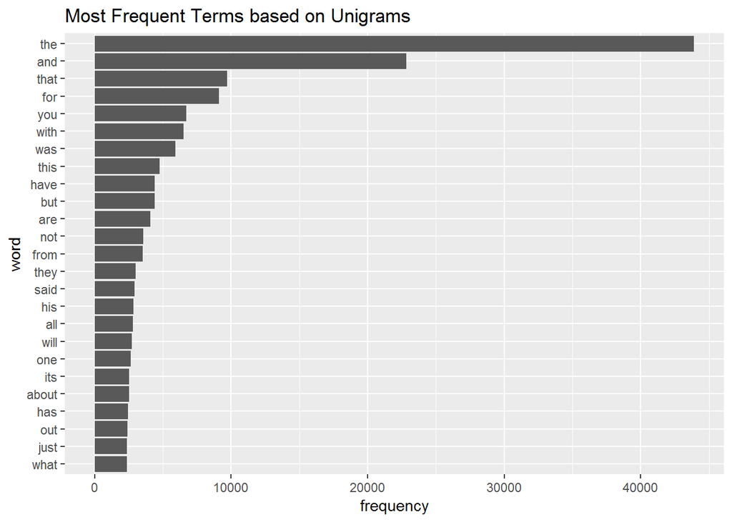

```r
# Build Term document matrix with single tokenizer and words smaller than 3 characters are omitted
sampleTDM <- tm::TermDocumentMatrix(sampleCorpora, control = list(wordLengths = c(3,Inf)))

#Put word count from TDM to data frame
sampleFreqWords <- data.frame(word = sampleTDM$dimnames$Terms, frequency = sampleTDM$v)

## Reorder the word list in descending order
sampleFreqWords <- plyr::arrange(sampleFreqWords, -frequency)

## Build Most frequent terms
n <- 25L # variable to set top n words
# isolate top n words by decreasing frequency
sampleFreqWords.top <- sampleFreqWords[1:n, ]
# reorder levels so charts plot in order of frequency
sampleFreqWords.top$word <- reorder(sampleFreqWords.top$word, sampleFreqWords.top$frequency)

# plots
g.sampleFreqWords.top <- ggplot(sampleFreqWords.top, aes(x = word, y = frequency))
g.sampleFreqWords.top <- g.sampleFreqWords.top + geom_bar(stat = "identity") + coord_flip() + labs(title = "Most Frequent Terms based on Unigrams")
g.sampleFreqWords.top
```

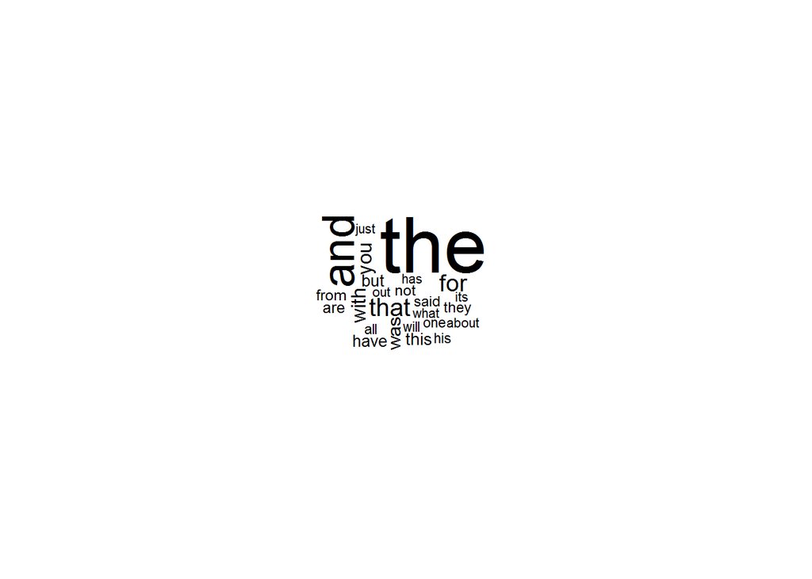

```r
# Plot a wordcloud of Unigrams
wordcloud(sampleFreqWords.top$word, sampleFreqWords.top$frequency, max.words = 50)
```

### Next Steps Forward - Prediction Algorithm

Moving forward, the project goal is to develop a natural language prediction algorithm and app. For example, if a user were to type, “I want to go to the .”, the app would suggest the three most likely words that would replace “.”.

#### N-gram Dictionary

```r
# tokenizer functions
UniGramTokenizer = function (corpus) {
  NGramTokenizer (corpus, Weka_control (min = 1, max = 1))
}

BiGramTokenizer = function (corpus) {
  NGramTokenizer (corpus, Weka_control (min = 2, max = 2))
}

TriGramTokenizer = function (corpus) {
  NGramTokenizer (corpus, Weka_control (min = 3, max = 3))
}

TetraGramTokenizer = function (corpus) {
  NGramTokenizer (corpus, Weka_control (min = 4, max = 4))
}

##sample Trigram analysis - Most frequent terms
trigram.sampleTDM <- tm::TermDocumentMatrix(sampleCorpora, control = list(tokenize = TriGramTokenizer))
# put into data frame
freq.trigram <- data.frame(word = trigram.sampleTDM$dimnames$Terms, frequency = trigram.sampleTDM$v)
# reorder by descending frequency
freq.trigram <- plyr::arrange(freq.trigram, -frequency)

## Extract most frequent tri-grams
head(freq.trigram,25)
```

```
##              word frequency
## 1      one of the       330
## 2        a lot of       284
## 3         the u s       166
## 4         to be a       152
## 5      as well as       147
## 6      the end of       139
## 7     going to be       137
## 8         i don t       134
## 9      out of the       129
## 10    some of the       124
## 11       it was a       122
## 12      i want to       119
## 13    part of the       118
## 14     be able to       110
## 15 thanks for the       108
## 16    a couple of       104
## 17 the first time       102
## 18    you have to        96
## 19       i have a        95
## 20     there is a        94
## 21      this is a        93
## 22     end of the        91
## 23    the rest of        89
## 24  the fact that        88
## 25    is going to        86
```

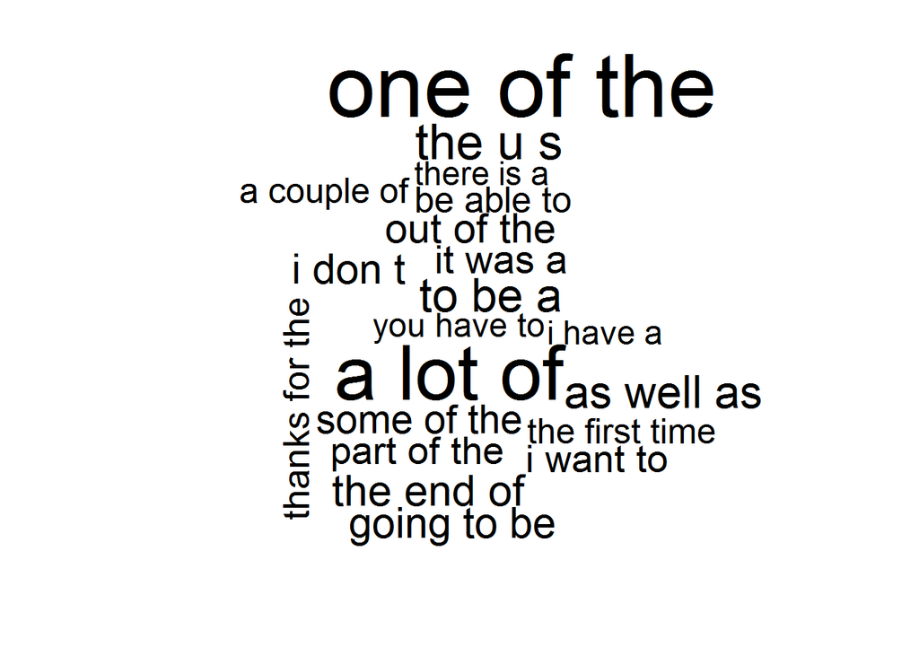

```r
# Plot a wordcloud of Trigrams
wordcloud(freq.trigram$word, freq.trigram$frequency, max.words = 20)
```

#### Predicting from N-grams

Each n-gram will be split, separating the last word from the previous words in the n-gram. - bigrams will become unigram/unigram pairs - trigrams will become bigram/unigram pairs - four-grams will become trigram/unigram pairs

```r
freq.trigram %>% filter(str_detect(freq.trigram$word,"^cant wait"))
```

```
##               word frequency
## 1     cant wait to        47
## 2    cant wait for        16
## 3   cant wait till         7
## 4  cant wait until         3
## 5     cant wait my         2
## 6    cant wait any         1
## 7    cant wait but         1
## 8   cant wait good         1
## 9    cant wait ily         1
## 10    cant wait rt         1
## 11     cant wait y         1
```

#### Application Logic

After the dictionaries have been established, an app will be developed allowing the user to enter text. The app will suggest the three most likely words to come next in the text for the text type, based on these rules.

If the supplied text is greater than 2 words, take the last three words of the text and search the trigram/unigram pairs. If the supplied text is 2 words, take the two words and search the bigram/unigram pairs. If the supplied text is 1 word, search for that word in the unigram/unigram pairs. Suggest the three most frequent unigrams from the n-gram/unigram pair for either 1, 2, or 3 above.